# Question 6

Sujay Chebbi

8/17/2020

## Question 6 - Association Rule Mining

reads groceries text file as transaction dataset and inspects the first 6 baskets

```r
groceries = read.transactions(file = "https://raw.githubusercontent.com/jgscott/STA380/master/data/groceries.txt",
                          format = c("basket"), sep = ",")

arules::inspect(head(groceries))
```

```
##     items
## [1] {citrus fruit,
##      margarine,
##      ready soups,
##      semi-finished bread}
## [2] {coffee,
##      tropical fruit,
##      yogurt}
## [3] {whole milk}
## [4] {cream cheese,
##      meat spreads,
##      pip fruit,
##      yogurt}
## [5] {condensed milk,
##      long life bakery product,
##      other vegetables,
##      whole milk}
## [6] {abrasive cleaner,
##      butter,
##      rice,
##      whole milk,
##      yogurt}
```

gathers most frequent items in dataset, filtered by decreasing support and inspects the 15 most frequent items in any basket

```r
FrequentItems = eclat(groceries, parameter = list(support = 0.05))
```

```
## Eclat
##
## parameter specification:
##  tidLists support minlen maxlen            target  ext
##     FALSE    0.05      1     10 frequent itemsets TRUE
##
## algorithmic control:
##  sparse sort verbose
##       7   -2    TRUE
##
## Absolute minimum support count: 491
##
## create itemset ...
## set transactions ...[169 item(s), 9835 transaction(s)] done [0.00s].
## sorting and recoding items ... [28 item(s)] done [0.00s].
## creating sparse bit matrix ... [28 row(s), 9835 column(s)] done [0.00s].
## writing  ... [31 set(s)] done [0.00s].
## Creating S4 object  ... done [0.00s].
```

```r
FrequentItems <- sort(FrequentItems, by = "support", decreasing = TRUE)
arules::inspect(head(FrequentItems, 15))
```

```
##      items              support    transIdenticalToItemsets count
## [1]  {whole milk}       0.25551601 2513                     2513
## [2]  {other vegetables} 0.19349263 1903                     1903
## [3]  {rolls/buns}       0.18393493 1809                     1809
## [4]  {soda}             0.17437722 1715                     1715
## [5]  {yogurt}           0.13950178 1372                     1372
## [6]  {bottled water}    0.11052364 1087                     1087
## [7]  {root vegetables}  0.10899847 1072                     1072
## [8]  {tropical fruit}   0.10493137 1032                     1032
## [9]  {shopping bags}    0.09852567  969                      969
## [10] {sausage}          0.09395018  924                      924
## [11] {pastry}           0.08896797  875                      875
## [12] {citrus fruit}     0.08276563  814                      814
## [13] {bottled beer}     0.08052872  792                      792
## [14] {newspapers}       0.07981698  785                      785
## [15] {canned beer}      0.07768175  764                      764
```

plotting absolute frequency of top 15 items in groceries dataset

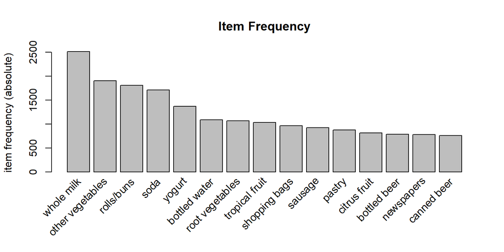

plotting relative frequency of top 15 items in dataset

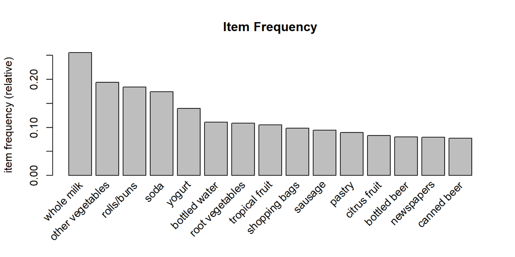

32791 rules created, and we inspect the first 6 association rules

```r
groceryRules <- apriori(groceries, parameter = list(support = 0.001, confidence = 0.1))
```

```
## Apriori
##
## Parameter specification:
##  confidence minval smax arem  aval originalSupport maxtime support minlen
##         0.1    0.1    1 none FALSE            TRUE       5   0.001      1
##  maxlen target  ext
##      10  rules TRUE
##
## Algorithmic control:
##  filter tree heap memopt load sort verbose
##     0.1 TRUE TRUE  FALSE TRUE    2    TRUE
##
## Absolute minimum support count: 9
##
## set item appearances ...[0 item(s)] done [0.00s].
## set transactions ...[169 item(s), 9835 transaction(s)] done [0.00s].
## sorting and recoding items ... [157 item(s)] done [0.00s].
## creating transaction tree ... done [0.00s].
## checking subsets of size 1 2 3 4 5 6 done [0.01s].
## writing ... [32791 rule(s)] done [0.00s].
## creating S4 object  ... done [0.01s].
```

```r
arules::inspect(head(groceryRules))
```

```
##     lhs    rhs               support   confidence coverage lift count
## [1] {}  => {bottled water}   0.1105236 0.1105236  1        1    1087
## [2] {}  => {tropical fruit}  0.1049314 0.1049314  1        1    1032
## [3] {}  => {root vegetables} 0.1089985 0.1089985  1        1    1072
## [4] {}  => {soda}            0.1743772 0.1743772  1        1    1715
## [5] {}  => {yogurt}          0.1395018 0.1395018  1        1    1372
## [6] {}  => {rolls/buns}      0.1839349 0.1839349  1        1    1809
```

creating a new rules matrix that sorts grocery rules by decreasing support, and we inspect the first 15 association rules of this new rules matrix

```r
rulesSupport <- sort(groceryRules, by = "support", decreasing = TRUE)
arules::inspect(head(rulesSupport, 15))
```

```
##      lhs                   rhs                support    confidence coverage
## [1]  {}                 => {whole milk}       0.25551601 0.2555160  1.0000000
## [2]  {}                 => {other vegetables} 0.19349263 0.1934926  1.0000000
## [3]  {}                 => {rolls/buns}       0.18393493 0.1839349  1.0000000
## [4]  {}                 => {soda}             0.17437722 0.1743772  1.0000000
## [5]  {}                 => {yogurt}           0.13950178 0.1395018  1.0000000
## [6]  {}                 => {bottled water}    0.11052364 0.1105236  1.0000000
## [7]  {}                 => {root vegetables}  0.10899847 0.1089985  1.0000000
## [8]  {}                 => {tropical fruit}   0.10493137 0.1049314  1.0000000
## [9]  {other vegetables} => {whole milk}       0.07483477 0.3867578  0.1934926
## [10] {whole milk}       => {other vegetables} 0.07483477 0.2928770  0.2555160
## [11] {rolls/buns}       => {whole milk}       0.05663447 0.3079049  0.1839349
## [12] {whole milk}       => {rolls/buns}       0.05663447 0.2216474  0.2555160
## [13] {yogurt}           => {whole milk}       0.05602440 0.4016035  0.1395018
## [14] {whole milk}       => {yogurt}           0.05602440 0.2192598  0.2555160
```

[output cut: 17 more lines]

creating a new rules matrix that sorts grocery rules by decreasing confidence, and we inspect the first 15 associations rules of this new rules matrix

```r
rulesConfidence <- sort(groceryRules, by = "confidence", decreasing = TRUE)
arules::inspect(head(rulesConfidence, 15))
```

```
##      lhs                     rhs                    support confidence    coverage     lift count
## [1]  {rice,
##       sugar}              => {whole milk}       0.001220132          1 0.001220132 3.913649    12
## [2]  {canned fish,
##       hygiene articles}   => {whole milk}       0.001118454          1 0.001118454 3.913649    11
## [3]  {butter,
##       rice,
##       root vegetables}    => {whole milk}       0.001016777          1 0.001016777 3.913649    10
## [4]  {flour,
##       root vegetables,
##       whipped/sour cream} => {whole milk}       0.001728521          1 0.001728521 3.913649    17
## [5]  {butter,
##       domestic eggs,
##       soft cheese}        => {whole milk}       0.001016777          1 0.001016777 3.913649    10
## [6]  {citrus fruit,
##       root vegetables,
##       soft cheese}        => {other vegetables} 0.001016777          1 0.001016777 5.168156    10
## [7]  {butter,
##       hygiene articles,
##       pip fruit}          => {whole milk}       0.001016777          1 0.001016777 3.913649    10
## [8]  {hygiene articles,
##       root vegetables,
##       whipped/sour cream} => {whole milk}       0.001016777          1 0.001016777 3.913649    10
## [9]  {hygiene articles,
##       pip fruit,
##       root vegetables}    => {whole milk}       0.001016777          1 0.001016777 3.913649    10
## [10] {cream cheese,
##       domestic eggs,
##       sugar}              => {whole milk}       0.001118454          1 0.001118454 3.913649    11
## [11] {curd,
##       domestic eggs,
##       sugar}              => {whole milk}       0.001016777          1 0.001016777 3.913649    10
## [12] {cream cheese,
##       domestic eggs,
##       napkins}            => {whole milk}       0.001118454          1 0.001118454 3.913649    11
## [13] {brown bread,
##       pip fruit,
##       whipped/sour cream} => {other vegetables} 0.001118454          1 0.001118454 5.168156    11
## [14] {grapes,
##       tropical fruit,
##       whole milk,
##       yogurt}             => {other vegetables} 0.001016777          1 0.001016777 5.168156    10
## [15] {ham,
##       pip fruit,
##       tropical fruit,
##       yogurt}             => {other vegetables} 0.001016777          1 0.001016777 5.168156    10
```

creating a new rules matrix that sorts grocery rules by decreasing lift, and we inspect the first 15 association rules of this new rules matrix

```r
rulesLift <- sort(groceryRules, by = "lift", decreasing = TRUE)
arules::inspect(head(rulesLift, 15))
```

```
##      lhs                        rhs                         support confidence    coverage     lift count
## [1]  {bottled beer,
##       red/blush wine}        => {liquor}                0.001931876  0.3958333 0.004880529 35.71579    19
## [2]  {hamburger meat,
##       soda}                  => {Instant food products} 0.001220132  0.2105263 0.005795628 26.20919    12
## [3]  {ham,
##       white bread}           => {processed cheese}      0.001931876  0.3800000 0.005083884 22.92822    19
## [4]  {other vegetables,
##       root vegetables,
##       whole milk,
##       yogurt}                => {rice}                  0.001321810  0.1688312 0.007829181 22.13939    13
## [5]  {bottled beer,
##       liquor}                => {red/blush wine}        0.001931876  0.4130435 0.004677173 21.49356    19
## [6]  {Instant food products,
##       soda}                  => {hamburger meat}        0.001220132  0.6315789 0.001931876 18.99565    12
## [7]  {curd,
##       sugar}                 => {flour}                 0.001118454  0.3235294 0.003457041 18.60767    11
## [8]  {salty snack,
##       soda}                  => {popcorn}               0.001220132  0.1304348 0.009354347 18.06797    12
## [9]  {baking powder,
##       sugar}                 => {flour}                 0.001016777  0.3125000 0.003253686 17.97332    10
## [10] {processed cheese,
##       white bread}           => {ham}                   0.001931876  0.4634146 0.004168785 17.80345    19
## [11] {fruit/vegetable juice,
##       ham}                   => {processed cheese}      0.001118454  0.2894737 0.003863752 17.46610    11
## [12] {margarine,
##       sugar}                 => {flour}                 0.001626843  0.2962963 0.005490595 17.04137    16
## [13] {root vegetables,
##       sugar,
##       whole milk}            => {flour}                 0.001016777  0.2941176 0.003457041 16.91606    10
## [14] {popcorn,
##       soda}                  => {salty snack}           0.001220132  0.6315789 0.001931876 16.69779    12
## [15] {baking powder,
##       flour}                 => {sugar}                 0.001016777  0.5555556 0.001830198 16.40807    10
```

There are 28 different association rules where confidence = 1. Notice that the support remains relatively low, hovering around 0.001. Lift for these rules tends to be about 4 or 5.

```r
arules::inspect(subset(rulesConfidence, subset = confidence == 1))
```

```
##      lhs                        rhs                    support confidence    coverage     lift count
## [1]  {rice,
##       sugar}                 => {whole milk}       0.001220132          1 0.001220132 3.913649    12
## [2]  {canned fish,
##       hygiene articles}      => {whole milk}       0.001118454          1 0.001118454 3.913649    11
## [3]  {butter,
##       rice,
##       root vegetables}       => {whole milk}       0.001016777          1 0.001016777 3.913649    10
## [4]  {flour,
##       root vegetables,
##       whipped/sour cream}    => {whole milk}       0.001728521          1 0.001728521 3.913649    17
## [5]  {butter,
##       domestic eggs,
##       soft cheese}           => {whole milk}       0.001016777          1 0.001016777 3.913649    10
## [6]  {citrus fruit,
##       root vegetables,
##       soft cheese}           => {other vegetables} 0.001016777          1 0.001016777 5.168156    10
## [7]  {butter,
##       hygiene articles,
##       pip fruit}             => {whole milk}       0.001016777          1 0.001016777 3.913649    10
## [8]  {hygiene articles,
##       root vegetables,
##       whipped/sour cream}    => {whole milk}       0.001016777          1 0.001016777 3.913649    10
## [9]  {hygiene articles,
##       pip fruit,
##       root vegetables}       => {whole milk}       0.001016777          1 0.001016777 3.913649    10
## [10] {cream cheese,
##       domestic eggs,
##       sugar}                 => {whole milk}       0.001118454          1 0.001118454 3.913649    11
## [11] {curd,
##       domestic eggs,
##       sugar}                 => {whole milk}       0.001016777          1 0.001016777 3.913649    10
## [12] {cream cheese,
##       domestic eggs,
##       napkins}               => {whole milk}       0.001118454          1 0.001118454 3.913649    11
## [13] {brown bread,
##       pip fruit,
##       whipped/sour cream}    => {other vegetables} 0.001118454          1 0.001118454 5.168156    11
## [14] {grapes,
##       tropical fruit,
```

[output cut: 44 more lines]

```
##       tropical fruit,
##       whipped/sour cream}    => {other vegetables} 0.001220132          1 0.001220132 5.168156    12
## [26] {bottled water,
##       other vegetables,
##       pip fruit,
##       root vegetables}       => {whole milk}       0.001118454          1 0.001118454 3.913649    11
## [27] {rolls/buns,
##       root vegetables,
##       sausage,
##       tropical fruit}        => {whole milk}       0.001016777          1 0.001016777 3.913649    10
## [28] {oil,
##       other vegetables,
##       root vegetables,
##       tropical fruit,
##       yogurt}                => {whole milk}       0.001016777          1 0.001016777 3.913649    10
```

```r
arules::inspect(subset(rulesLift, subset = lift > 15))
```

```
##      lhs                        rhs                         support confidence    coverage     lift count
## [1]  {bottled beer,
##       red/blush wine}        => {liquor}                0.001931876  0.3958333 0.004880529 35.71579    19
## [2]  {hamburger meat,
##       soda}                  => {Instant food products} 0.001220132  0.2105263 0.005795628 26.20919    12
## [3]  {ham,
##       white bread}           => {processed cheese}      0.001931876  0.3800000 0.005083884 22.92822    19
## [4]  {other vegetables,
##       root vegetables,
##       whole milk,
##       yogurt}                => {rice}                  0.001321810  0.1688312 0.007829181 22.13939    13
## [5]  {bottled beer,
##       liquor}                => {red/blush wine}        0.001931876  0.4130435 0.004677173 21.49356    19
## [6]  {Instant food products,
##       soda}                  => {hamburger meat}        0.001220132  0.6315789 0.001931876 18.99565    12
## [7]  {curd,
##       sugar}                 => {flour}                 0.001118454  0.3235294 0.003457041 18.60767    11
## [8]  {salty snack,
##       soda}                  => {popcorn}               0.001220132  0.1304348 0.009354347 18.06797    12
## [9]  {baking powder,
##       sugar}                 => {flour}                 0.001016777  0.3125000 0.003253686 17.97332    10
## [10] {processed cheese,
##       white bread}           => {ham}                   0.001931876  0.4634146 0.004168785 17.80345    19
## [11] {fruit/vegetable juice,
##       ham}                   => {processed cheese}      0.001118454  0.2894737 0.003863752 17.46610    11
## [12] {margarine,
##       sugar}                 => {flour}                 0.001626843  0.2962963 0.005490595 17.04137    16
## [13] {root vegetables,
##       sugar,
##       whole milk}            => {flour}                 0.001016777  0.2941176 0.003457041 16.91606    10
## [14] {popcorn,
##       soda}                  => {salty snack}           0.001220132  0.6315789 0.001931876 16.69779    12
## [15] {baking powder,
##       flour}                 => {sugar}                 0.001016777  0.5555556 0.001830198 16.40807    10
## [16] {butter,
##       root vegetables,
##       whole milk}            => {rice}                  0.001016777  0.1234568 0.008235892 16.18930    10
## [17] {sugar,
##       whipped/sour cream}    => {baking powder}         0.001321810  0.2708333 0.004880529 15.30831    13
## [18] {soda,
##       white bread,
##       whole milk}            => {processed cheese}      0.001016777  0.2500000 0.004067107 15.08436    10
## [19] {ham,
##       processed cheese}      => {white bread}           0.001931876  0.6333333 0.003050330 15.04549    19
## [20] {Instant food products,
##       whole milk}            => {hamburger meat}        0.001525165  0.5000000 0.003050330 15.03823    15
```

As seen from the inspection of subsets above, the consequent(s) of 100% confidence rules are ‘whole milk’ and ‘other vegetables’. This makes sense seeing that people, in general, consume milk and vegetables often. The consequent(s) of high lift rules include liquor, instant food products, rice, hamburger meat, wine, and popcorn among others.

The plot confirms what was stated above. Individual data points are shaded by confidence, and the most confidence occurs at low support and low to medium levels of lift.

```
## To reduce overplotting, jitter is added! Use jitter = 0 to prevent jitter.
```

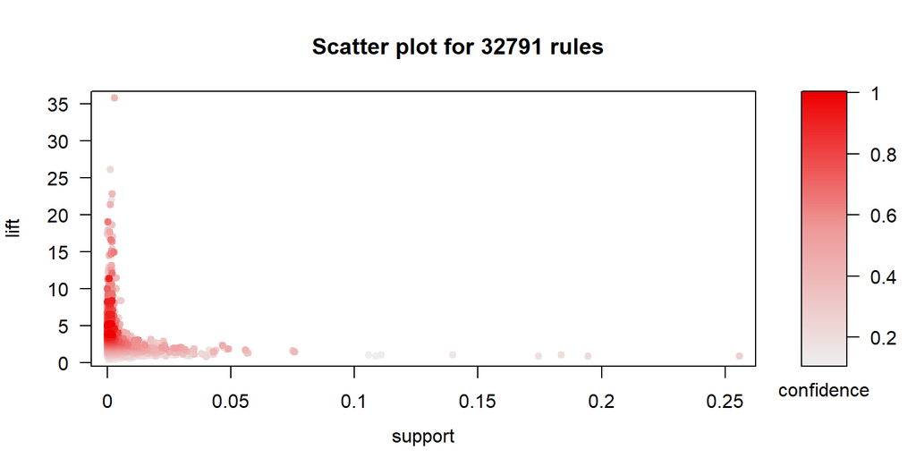

a subset of rules with confidence > 0.1 and support > 0.01 was created, and we inspect the first 6 association rules of this new rules matrix which contains 435 rules

```r
sub1 = subset(groceryRules, subset = confidence > 0.1 & support > 0.01)
arules::inspect(head(sub1))
```

```
##     lhs    rhs               support   confidence coverage lift count
## [1] {}  => {bottled water}   0.1105236 0.1105236  1        1    1087
## [2] {}  => {tropical fruit}  0.1049314 0.1049314  1        1    1032
## [3] {}  => {root vegetables} 0.1089985 0.1089985  1        1    1072
## [4] {}  => {soda}            0.1743772 0.1743772  1        1    1715
## [5] {}  => {yogurt}          0.1395018 0.1395018  1        1    1372
## [6] {}  => {rolls/buns}      0.1839349 0.1839349  1        1    1809
```

A graph of 50 rules, sorted by the highest lift based on the subset given above: confidence > 0.1 and support> 0.01.

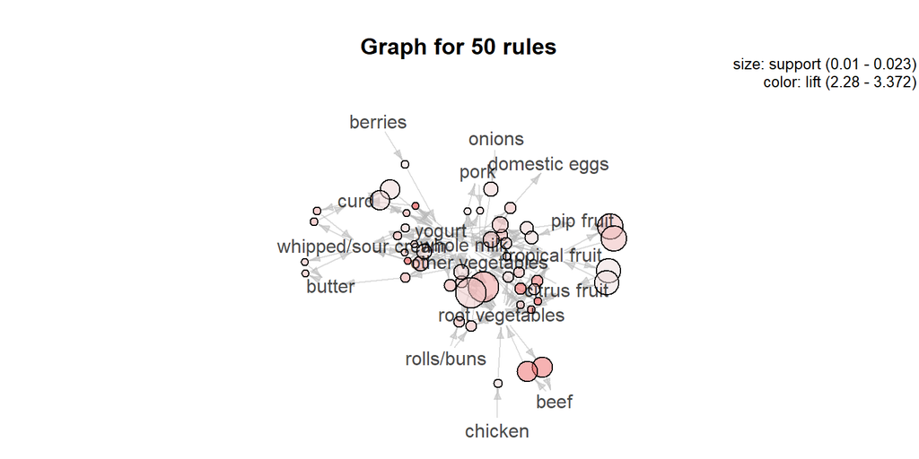

saved a graphml file containing 1084 nodes and 3907 edges of groceryRules. The file will be uploaded onto github and a screenshot of the gephi-produced graph is seen underneath this text block. Some characteristics of the network are listed below. Network diameter = 14 Graph Density = 0.003 Modularity = 0.331 Avg Path Length = 4.537

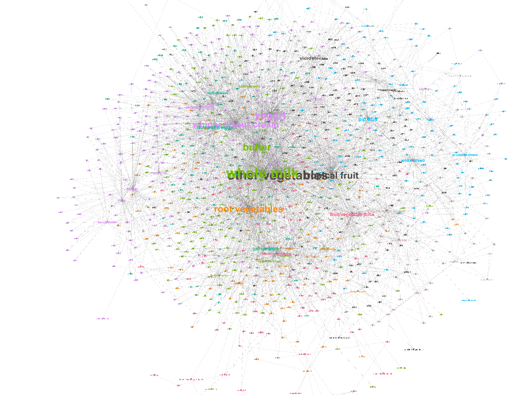

Grocery Rules

```r
#saveAsGraph(head(groceryRules, n = 1000, by = "lift"), file = "groceryRules.graphml")
```